# Understanding and Exploring Customer Insurtance Data

### Context:

Leveraging customer information is of atmost importance for the Helathcare Insurance Sector. Understanding and Exploring the insurance data will provide valuable insights for the Helathcare Insurance business.

1. It will help in price optimization to provide better service at cost effective premiums thereby maximizing profits and maintaining customer loyalty.
2. It will also help with customer segmentation so that insurance products can be better positioned for specific customer expectations.
3. It will help in risk assessment to assess the individual and group risks so that appropriate costs can be factored while pricing the insurance products.

### About the Data:

The data in context is about Customer Insurance information. The information contains data such as:

1. Age: age of primary beneficiary
2. Sex: insurance contractor gender, female, male
3. BMI: Body mass index, providing an understanding of body, weights that are relatively high or low relative to height, objective index of body weight (kg / m ^ 2) using the ratio of height to weight, ideally 18.5 to 24.9
4. Children: Number of children covered by health insurance / Number of dependents
5. Smoker: Smoking
6. Region: the beneficiary's residential area in the US, northeast, southeast, southwest, northwest.
7. Charges: Individual medical costs billed by health insurance.

### Objective

Deep dive into the data for valuable insights and conduct:

1. Statistical analysis
2. Exploratory Data Analysis
3. Hypothesis Testing

#### 1. IMPORT THE NECESSARY LIBRARIES

```python
%matplotlib inline
import numpy as np
import pandas as pd
import matplotlib.pyplot as plt
import seaborn as sns
import scipy.stats as stats
sns.set(style="darkgrid")
import copy
import os
```

#### 2. READ THE DATA AS A DATAFRAME

```python
mydata = pd.read_csv('Data Set - Insurance.csv')
```

#### 3. PERFORM BASIC EDA

Check if the dataframe has the right type of data and attributes -- Not for Grading

```python
mydata.head()
```

|  | age | sex | bmi | children | smoker | region | charges |
| --- | --- | --- | --- | --- | --- | --- | --- |
| 0 | 19 | female | 27.900 | 0 | yes | southwest | 16884.92400 |
| 1 | 18 | male | 33.770 | 1 | no | southeast | 1725.55230 |
| 2 | 28 | male | 33.000 | 3 | no | southeast | 4449.46200 |
| 3 | 33 | male | 22.705 | 0 | no | northwest | 21984.47061 |
| 4 | 32 | male | 28.880 | 0 | no | northwest | 3866.85520 |

##### 3a. EDA - Shape of Data

Print size and shape of the Insurance dataframe

```python
print(mydata.size)
print(mydata.shape)
```

```
9366
(1338, 7)
```

*The Insurance dataframe contains 9366 data elements and consists of 1338 rows by 7 columns.*

##### 3b. EDA - Data Type of each attribute

Dataypes of all columns in the dataframe:

```python
mydata.dtypes
```

```
age           int64
sex          object
bmi         float64
children      int64
smoker       object
region       object
charges     float64
dtype: object
```

Detailed information about datatypes. This will provide a short summary and full summary of the dataframe along with not null

```python
print("Short summary of Insurance Dataframe")
print("====================================")
mydata.info(verbose=False)
print("\n")
print("Full summary of Insurance Dataframe")
print("===================================")
mydata.info()
```

```
Short summary of Insurance Dataframe
====================================
<class 'pandas.core.frame.DataFrame'>
RangeIndex: 1338 entries, 0 to 1337
Columns: 7 entries, age to charges
dtypes: float64(2), int64(2), object(3)
memory usage: 73.3+ KB


Full summary of Insurance Dataframe
===================================
<class 'pandas.core.frame.DataFrame'>
RangeIndex: 1338 entries, 0 to 1337
Data columns (total 7 columns):
 #   Column    Non-Null Count  Dtype
---  ------    --------------  -----
 0   age       1338 non-null   int64
 1   sex       1338 non-null   object
 2   bmi       1338 non-null   float64
 3   children  1338 non-null   int64
 4   smoker    1338 non-null   object
 5   region    1338 non-null   object
 6   charges   1338 non-null   float64
dtypes: float64(2), int64(2), object(3)
memory usage: 73.3+ KB
```

##### 3c. EDA - Checking the Presence of missing values

Checking for the presence of missing values in the dataframe using isnull() a.k.a isna(). There are no missing values for the dataframe columns.

```python
mydata.isna().sum()
```

```
age         0
sex         0
bmi         0
children    0
smoker      0
region      0
charges     0
dtype: int64
```

Checking for the presence of not null values in the dataframe using notnull(). There are no missing values for the dataframe columns.

```python
mydata.notnull().count()
```

```
age         1338
sex         1338
bmi         1338
children    1338
smoker      1338
region      1338
charges     1338
dtype: int64
```

##### 3d. EDA - 5 point summary of numerical attributes - A statistical description of the dataframe

View a 5 point summary of numerical attributes

```python
mydata.describe(percentiles=None, include=None, exclude=None)
```

|  | age | bmi | children | charges |
| --- | --- | --- | --- | --- |
| count | 1338.000000 | 1338.000000 | 1338.000000 | 1338.000000 |
| mean | 39.207025 | 30.663397 | 1.094918 | 13270.422265 |
| std | 14.049960 | 6.098187 | 1.205493 | 12110.011237 |
| min | 18.000000 | 15.960000 | 0.000000 | 1121.873900 |
| 25% | 27.000000 | 26.296250 | 0.000000 | 4740.287150 |
| 50% | 39.000000 | 30.400000 | 1.000000 | 9382.033000 |
| 75% | 51.000000 | 34.693750 | 2.000000 | 16639.912515 |
| max | 64.000000 | 53.130000 | 5.000000 | 63770.428010 |

Alternatively a 5-point summary for a specific column from the dataframe can be obtained using

```python
mydata.age.describe()
```

```
count    1338.000000
mean       39.207025
std        14.049960
min        18.000000
25%        27.000000
50%        39.000000
75%        51.000000
max        64.000000
Name: age, dtype: float64
```

##### 3e. EDA - Distribution of ‘BMI’, ‘AGE’ and ‘CHARGES’ Columns

We will use Seaborn visualiztion library 'distplot' to plot the distributions of BMI, AGE AND CHARGES separately

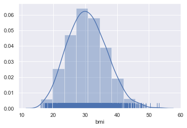

```python
bmi1=mydata['bmi'].dropna()
sns.distplot(bmi1,kde=True,rug=True, bins=10)
plt.show()
```

Likewise distributions for 'AGE' plotted using Seaborn distplot

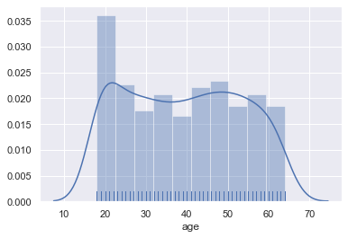

```python
age1=mydata['age'].dropna()
sns.distplot(age1,kde=True,rug=True, bins=10)
plt.show()
```

Likewise distributions for 'CHARGES' plotted using Seaborn distplot

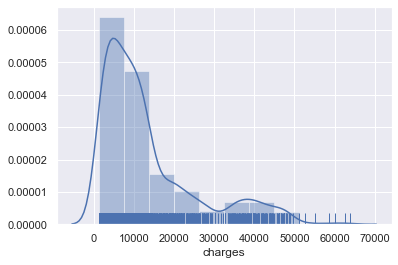

```python
charges1=mydata['charges'].dropna()
sns.distplot(charges1,kde=True,rug=True,bins=10)
plt.show()
```

##### Alternatively to observe the distribution between pair of variables and their relationship

we use the seaborn visualization library 'pairplot' as below.

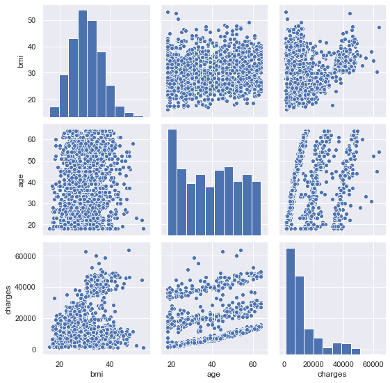

```python
sns.pairplot(mydata,vars=['bmi','age','charges'])
```

##### 3f. EDA - MEASURE OF SKEWNESS OF BMI, AGE, AND CHARGES COLUMNS

Skewness is a measure of assymetry of a distribution.

   **Skewness for Age, BMI and Charges**

```python
skewValue = mydata.skew(axis = 0, skipna = True)
print(skewValue)
```

```
age         0.055673
bmi         0.284047
children    0.938380
charges     1.515880
dtype: float64
```

Hence,

1. 'age' is skewed to the right (positively skewed).
2. 'bmi' is skewed to the right (positively skewed).
3. 'charges' is skewed to the right (positively skewed).

*Alternatively, the above can also be deduced by computing the statistical 5-number summary for the measures as follows.*

**The 5-Number Summary:** Compute the 5-Number Summary:

1. Minimum.
2. Q1.
3. Median(Q2).
4. Q3.
5. Max

```python
mydata.describe(percentiles=None, include=None, exclude=None)
```

|  | age | bmi | children | charges |
| --- | --- | --- | --- | --- |
| count | 1338.000000 | 1338.000000 | 1338.000000 | 1338.000000 |
| mean | 39.207025 | 30.663397 | 1.094918 | 13270.422265 |
| std | 14.049960 | 6.098187 | 1.205493 | 12110.011237 |
| min | 18.000000 | 15.960000 | 0.000000 | 1121.873900 |
| 25% | 27.000000 | 26.296250 | 0.000000 | 4740.287150 |
| 50% | 39.000000 | 30.400000 | 1.000000 | 9382.033000 |
| 75% | 51.000000 | 34.693750 | 2.000000 | 16639.912515 |
| max | 64.000000 | 53.130000 | 5.000000 | 63770.428010 |

*The relationship between the 5-number summaries can also determine the distribution shape.*

**For Age:**

Median - Min = 39.00 - 18.00 = 21.00

Max - Median = 64.00 - 39.00 = 25.00

Q1 - Min = 27.00 - 18.00 = 9.00

Max - Q3 = 64.00 - 51.00 = 13.00

Since,

> Max-Median > Median-Min

and

> Max-Q3 > Q1-Min

and

the 'Age' distribution curve is Right-Skewed.

*Likewise the relationship for the 5-Number summaries of 'BMI' and 'Charges' can also be computed to determine that they are **Right-Skewed.***

##### 3g. EDA - Checking the presence of outliers in ‘bmi’, ‘age’ & ‘charges columns via boxplot

*Outliers are extreme values that deviate from other observations on data an can indicate a variability in measurement, an experimental error or a novelty. In other words, outliers diverges from the overall pattern on a sample. Outliers for the Insurance data have been detected using both the*

1. 'Box plot'

and

2. 'Z-score'

methods below:

**1. Box plot method**

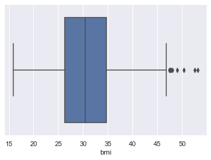

```python
plt.subplot()
sns.boxplot(mydata['bmi'])
```

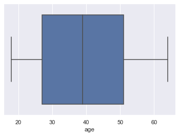

```python
sns.boxplot(mydata['age'])
```

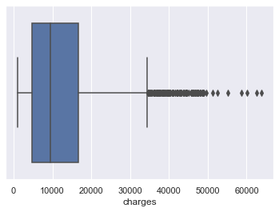

```python
sns.boxplot(mydata['charges'])
```

**2. Z-score method** Z-score indicates the number of standard deviations from the mean and when the threshold score is greater than 3 or less than -3, it is considered an outllier. The below code identifiers the outliers for each of the variables 'age', 'bmi' and 'charges' and outputs the resulting dataframe with outlier data.

```python
############Code to identify the dataframe outliers for certain variables and output combined df"
#Drop the columns for which z-score is not required
mydata1 = mydata.drop(['sex','children','smoker','region'],axis=1)
#Create a list of columns to loop over
cols = list(mydata1.columns)
# Define z-score threshold value
threshold1 = 3.00
threshold2 = -3.00
#Iterate over the remaining columns and create a z-score column
for col1 in cols:

    col_zscore = col1 + '_zscore'

    mydata1[col_zscore] = (mydata1[col1] - mydata1[col1].mean())/mydata1[col1].std()

mydata1
# selecting rows based on age_zscore > 3 or < -3
out_age_df = mydata1.loc[mydata1['age_zscore'] > threshold1] | mydata1.loc[mydata1['age_zscore'] < threshold2]
# selecting rows based on bmi_zscore > 3 or < -3
out_bmi_df = mydata1.loc[np.logical_or(mydata1['bmi_zscore'] > 3, mydata1['bmi_zscore'] < -3 )]
# selecting rows based on charges_zscore > 3 or < -3
out_charges_df = mydata1.loc[np.logical_or(mydata1['charges_zscore'] > 3, mydata1['charges_zscore'] < -3 )]
#Appending the dataframes with outlier columns
rslt_df = out_age_df.append(out_bmi_df.append(out_charges_df))
rslt_df
```

|  | age | bmi | charges | age_zscore | bmi_zscore | charges_zscore |
| --- | --- | --- | --- | --- | --- | --- |
| 116 | 58 | 49.060 | 11381.32540 | 1.337582 | 3.016733 | -0.155995 |
| 847 | 23 | 50.380 | 2438.05520 | -1.153528 | 3.233191 | -0.894497 |
| 1047 | 22 | 52.580 | 44501.39820 | -1.224703 | 3.593954 | 2.578939 |
| 1317 | 18 | 53.130 | 1163.46270 | -1.509401 | 3.684145 | -0.999748 |
| 34 | 28 | 36.400 | 51194.55914 | -0.797655 | 0.940706 | 3.131635 |
| 543 | 54 | 47.410 | 63770.42801 | 1.052884 | 2.746161 | 4.170104 |
| 577 | 31 | 38.095 | 58571.07448 | -0.584132 | 1.218658 | 3.740761 |
| 819 | 33 | 35.530 | 55135.40209 | -0.441782 | 0.798041 | 3.457055 |
| 1146 | 60 | 32.800 | 52590.82939 | 1.479931 | 0.350367 | 3.246934 |
| 1230 | 52 | 34.485 | 60021.39897 | 0.910535 | 0.626679 | 3.860523 |
| 1300 | 45 | 30.360 | 62592.87309 | 0.412313 | -0.049752 | 4.072866 |

*The above dataframe contains all the rows where either of 'Age', 'BMI' or 'Charges' have outliers. It's evident from the above that the Customer Insurance data has 4 outliers in 'BMI' and 7 outliers in 'Charges'. As observed in Boxplot above, 'Age' does not have any outlier.*

##### 3h. EDA - Distribution of categorical columns (include children)

To explore the categorical distribution of Insurance data between **"charges"** and categorical variables **"sex", "children", "smoker" and "region"**, we will use the seaborn.catplot function with the "boxplot" representation.

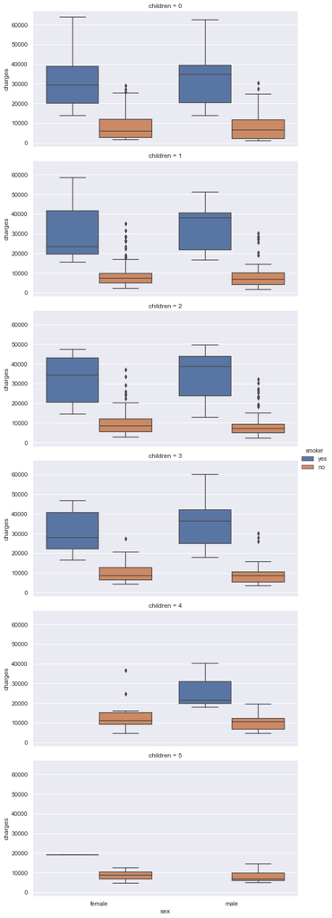

```python
sns.catplot(x="sex", y="charges",
            hue="smoker", row="children",
            data=mydata, kind="box",
           height=4, aspect=2)
```

Likewise, for the exploration of Insurance data between **"bmi"** and categorical variables **"sex", "children", "smoker" and "region"**, we will use the seaborn.catplot function with the "boxplot" representation.

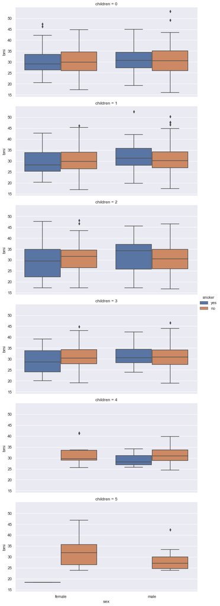

```python
sns.catplot(x="sex", y="bmi",
            hue="smoker", row="children",
            data=mydata, kind="box",
           height=4, aspect=2)
```

##### 3i. EDA - Pair plot that includes all the columns of the data frame

Pairplots are plotted to visualize relationships between numeric variables in a matrix generated by creating a grid of axes with each variable in data being shared in the y-axis across a single row and in the x-axis across a single column.

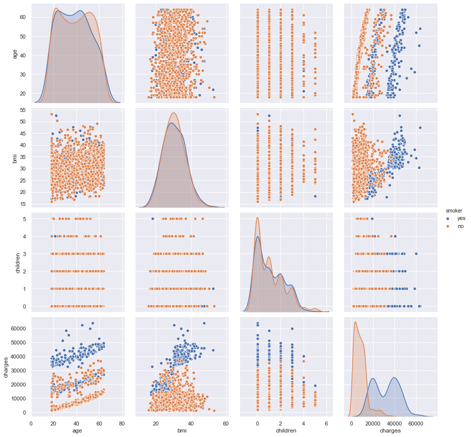

```python
sns.pairplot(mydata,hue='smoker',height=3)
```

The same pairplot can be generated with a hue="sex" as below:

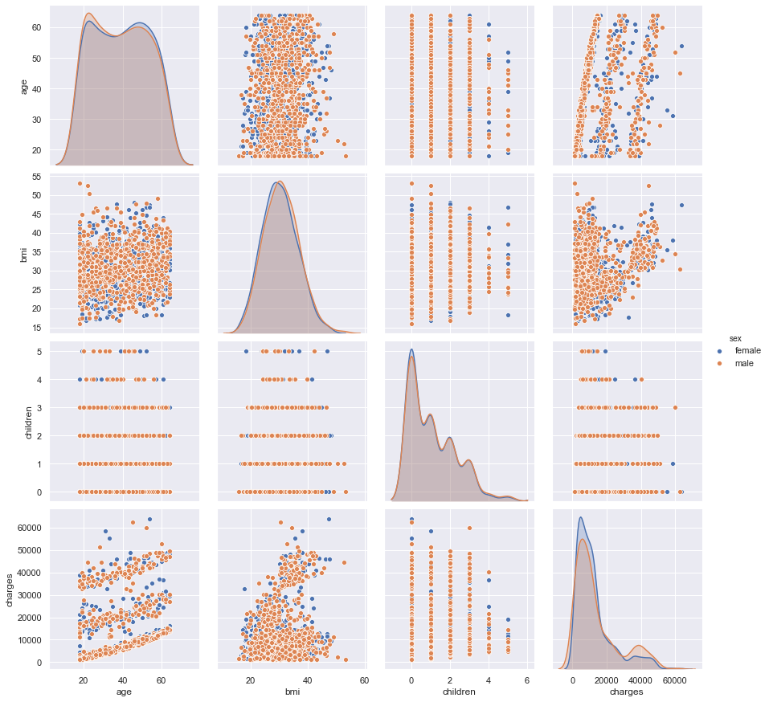

```python
sns.pairplot(mydata,hue='sex',height=3)
```

##### 4a. Do charges of people who smoke differ significantly from the people who don't?

**To determine if the charges of people who smoke differ significantly from those who don't, we can use a** :

1. Stripplot between 'charges' and 'smoker'to show the dependency between the two.
2. Scatterplot between two numeric variables such as 'charges' and 'age' while color encoding the 'smoker' categorical variable.
3. t-test to determine impact of smoking on charges.

**1. Stripplot between 'charges' and 'smoker'**

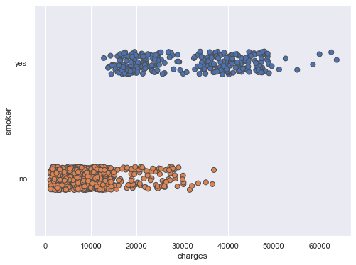

```python
plt.figure(figsize=(8,6))
sns.stripplot(x="charges", y="smoker", data=mydata, size=7, linewidth=1)
```

*From the stripplot() above, visually it is evident that people who smoke have higher charges than people who do not smoke. So charges of people who smoke differ significantly from those who don't.*

**2. Scatterplot between "charges" and "age" with a hue = "smoker"**

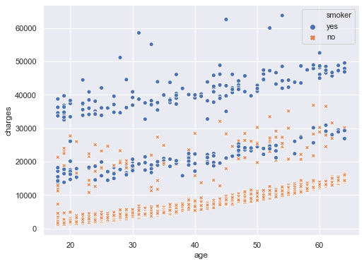

```python
plt.figure(figsize=(8,6))
sns.scatterplot(x="age", y="charges", hue="smoker", style="smoker", data=mydata)
```

*From the above scatterplot(), it is visually evident that charges of smokers is significantly different from those of non-smokers for different age groups. There are certain values of charges which do not vary much between smokers and non-smokers, but predominantly, for most of the data points there is significant diferrent in charges between the two categories.*

**3. T-test to determine the impact of smoking and non-smoking on charges**

*We will conduct an Independent t-test for the smokers and non-smokers to see if there is statistically significant difference in the mean of "charges" between the two groups.*

```python
#Applying T-test to determine whether there is a statistically significant difference in the means
#of charges between the two groups Smokers="Yes" and Smokers="No"
Ho = "Charges of smoker and non-smoker are same"   #State the Null Hypothesis
Ha = "Charges of smoker and non-smoker are not the same" # State the Alternate Hypothesis

x = np.array(mydata[mydata.smoker == 'yes'].charges)
# Selecting charges corresponding to smokers as an array
y = np.array(mydata[mydata.smoker == 'no'].charges)
# Selecting charges corresponding to non-smokers as an array

t, p_value  = stats.ttest_ind(x,y, axis = 0)  #Performing an Independent t-test

print(p_value)
```

```
8.271435842177219e-283
```

*Since the above p-value is significantly less than 0.05 (p-value < 0.05), we reject the null hypothesis that charges of smokers and non-smokers are the same. The Charges of Smokers and Non-Smokers are thus significantly different.*

##### 4b. Does bmi of males differ significantly from that of females?

*As above we can try to answer this visually via a stripplot & a scatter plot and via t-test to determine if there is a significant difference in bmi over sex.*

**1. Stripplot and Scatter Plot**

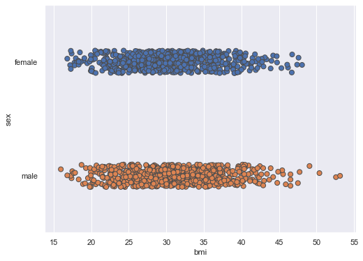

```python
plt.figure(figsize=(8,6))
sns.stripplot(x="bmi", y="sex", data=mydata, size=7, linewidth=1)
```

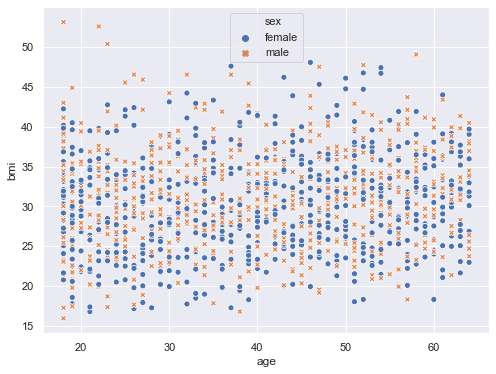

```python
plt.figure(figsize=(8,6))
sns.scatterplot(x="age", y="bmi", hue="sex", style="sex", data=mydata)
```

*From both the Stripplot and Scatter plot for "bmi" vs "sex" we cannot draw a clear conclusion that "bmi" of males significantly differ from that of females. Values of "bmi" do not vary much between males and females in the plots and hence its inconclusive. So visually there is not much difference in BMI between males and females*

**2. T-test to determine "bmi" statsitical difference of males and females.**

```python
#Applying T-test to determine whether there is a statistically significant difference in the means
#of "bmi" between the two groups Sex = "Male" and Sex = "Female"
Ho = "BMI of Males and Females are same"   #State the Null Hypothesis
Ha = "Charges of Males and Females are not the same" # State the Alternate Hypothesis

x = np.array(mydata[mydata.sex== 'male'].bmi)
# Selecting bmi corresponding to males as an array
y = np.array(mydata[mydata.sex == 'female'].bmi)
# Selecting bmi corresponding to females as an array

t, p_value  = stats.ttest_ind(x,y, axis = 0)  #Performing an Independent t-test

print(p_value)
```

```
0.08997637178984932
```

*As p-value > .05, we accept the Null-hypothesis and conclude that BMI of Males and Females statistically do not show significant difference. BMI of both genders are similar..*

##### 4c. Is the proportion of smokers significantly different in different genders?

We will try to determine the proportion of smokers across genders using:

chi-square test to examine the categorical relationship between smokers and genders

```python
# Chi_square test to check if smoking habits are different for different genders
Ho = "Proportion of smokers same across genders"   # Stating the Null Hypothesis
Ha = "Proportion of smokers significantly different across genders" # Stating the Alternate Hypothesis

# Compute a cross tab to group smokers and gender in a contingency table to analyze the correlation
# between the two variables.

crosstab = pd.crosstab(mydata['sex'],mydata['smoker'])

# Compute the chi-square statistic, p-value for hypothesis and degress of freedom
chi, p_value, dof, expected =  stats.chi2_contingency(crosstab)

if p_value < 0.05:  # Asusming a significance level of 5%
    print(f'{Ha} as the p_value ({p_value}) < 0.05')
else:
    print(f'{Ho} as the p_value ({p_value}) > 0.05')
crosstab
```

```
Proportion of smokers significantly different across genders as the p_value (0.006548143503580696) < 0.05
```

| smoker sex | no | yes |
| --- | --- | --- |
| female | 547 | 115 |
| male | 517 | 159 |

*Rejecting null hypothesis, we conclude that Proportion of smokers is significantly different across gender.*

##### 4d. Is the distribution of bmi across women with no children, one child and two children, the same ?

"bmi" values drawn across women with no children, one child and two children are independent and random

The "bmi" values are normally distributed.

The variances across the groups are equal

```python
# Applying a one-way  anova test to check the variance in bmi.
Ho = "No. of children has no effect on bmi"
Ha = "No. of children has an effect on bmi"

women_df = copy.deepcopy(mydata[mydata['sex'] == 'female'])

zero = women_df[women_df.children == 0]['bmi']
one  = women_df[women_df.children == 1]['bmi']
two  = women_df[women_df.children == 2]['bmi']

f_stat, p_value = stats.f_oneway(zero,one,two)
print(p_value)
```

```
0.7158579926754841
```

*Since p_value > .05, we accept the null hypothesis that BMI distribution is the same across women with different children groups.*